# Student 3000 Criminal Data

coop711

2018-04-02

## Biometrika 1908

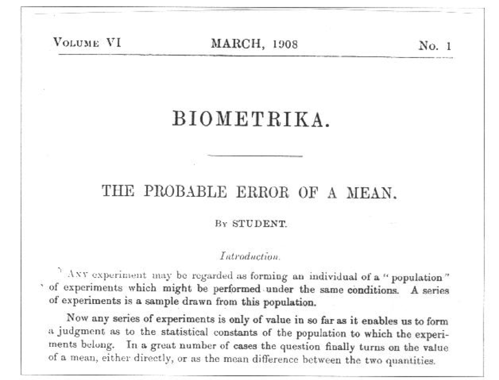

## Structure of Data

“Student”: William. S. Gosset(1876 ~ 1937)이 t-분포를 유도하기 위하여 모의실험에 활용한 자료는 다음과 같다.

```r
options(width = 80)
crimtab
```

```
##      142.24 144.78 147.32 149.86 152.4 154.94 157.48 160.02 162.56 165.1 167.64
## 9.4       0      0      0      0     0      0      0      0      0     0      0
## 9.5       0      0      0      0     0      1      0      0      0     0      0
## 9.6       0      0      0      0     0      0      0      0      0     0      0
## 9.7       0      0      0      0     0      0      0      0      0     0      0
## 9.8       0      0      0      0     0      0      1      0      0     0      0
## 9.9       0      0      1      0     1      0      1      0      0     0      0
## 10        1      0      0      1     2      0      2      0      0     1      0
## 10.1      0      0      0      1     3      1      0      1      1     0      0
## 10.2      0      0      2      2     2      1      0      2      0     1      0
## 10.3      0      1      1      3     2      2      3      5      0     0      0
## 10.4      0      0      1      1     2      3      3      4      3     3      0
## 10.5      0      0      0      1     3      7      6      4      3     1      3
## 10.6      0      0      0      1     4      5      9     14      6     3      1
## 10.7      0      0      1      2     4      9     14     16     15     7      3
## 10.8      0      0      0      2     5      6     14     27     10     7      1
## 10.9      0      0      0      0     2      6     14     24     27    14     10
## 11        0      0      0      2     6     12     15     31     37    27     17
## 11.1      0      0      0      3     3     12     22     26     24    26     24
## 11.2      0      0      0      3     2      7     21     30     38    29     27
## 11.3      0      0      0      1     0      5     10     24     26    39     26
## 11.4      0      0      0      0     3      4      9     29     56    58     26
## 11.5      0      0      0      0     0      5     11     17     33    57     38
## 11.6      0      0      0      0     2      1      4     13     37    39     48
## 11.7      0      0      0      0     0      2      9     17     30    37     48
## 11.8      0      0      0      0     1      0      2     11     15    35     41
## 11.9      0      0      0      0     1      1      2     12     10    27     32
## 12        0      0      0      0     0      0      1      4      8    19     42
## 12.1      0      0      0      0     0      0      0      2      4    13     22
## 12.2      0      0      0      0     0      0      1      2      5     6     23
## 12.3      0      0      0      0     0      0      0      0      4     8     10
## 12.4      0      0      0      0     0      0      1      1      1     2      7
## 12.5      0      0      0      0     0      0      0      1      0     1      3
## 12.6      0      0      0      0     0      0      0      0      0     1      0
## 12.7      0      0      0      0     0      0      0      0      0     1      1
## 12.8      0      0      0      0     0      0      0      0      0     0      1
## 12.9      0      0      0      0     0      0      0      0      0     0      0
## 13        0      0      0      0     0      0      0      0      0     0      3
## 13.1      0      0      0      0     0      0      0      0      0     0      0
## 13.2      0      0      0      0     0      0      0      0      0     0      1
```

[output cut: 31 more lines]

```
## 12.1     28     15     27    10      4      1      0      0     0      0      0
## 12.2     17     16     11     8      1      1      0      0     0      0      0
## 12.3     13     20     23     6      5      0      0      0     0      0      0
## 12.4     12      4      7     7      1      0      0      1     0      0      0
## 12.5     12     11      8     6      8      0      2      0     0      0      0
## 12.6      3      5      7     8      6      3      1      1     0      0      0
## 12.7      7      5      5     8      2      2      0      0     0      0      0
## 12.8      2      3      1     8      5      3      1      1     0      0      0
## 12.9      1      2      2     0      1      1      0      0     0      0      0
## 13        0      1      0     1      0      2      1      0     0      0      0
## 13.1      1      1      0     0      0      0      0      0     0      0      0
## 13.2      1      0      1     0      3      0      0      0     0      0      0
## 13.3      0      0      0     0      0      1      0      1     0      0      0
## 13.4      0      0      0     0      0      0      0      0     0      0      0
## 13.5      0      0      0     0      0      0      1      0     0      0      0
```

```r
str(crimtab)
```

```
##  'table' int [1:42, 1:22] 0 0 0 0 0 0 1 0 0 0 ...
##  - attr(*, "dimnames")=List of 2
##   ..$ : chr [1:42] "9.4" "9.5" "9.6" "9.7" ...
##   ..$ : chr [1:22] "142.24" "144.78" "147.32" "149.86" ...
```

자료구조에서 살필 수 있다시피 손가락 길이와 키를 계급으로 나누고 손가락 길이와 키의 조합을 이름으로 갖는 `table`이다. 각 cell의 값은 길이와 키의 조합이 나타나는 빈도이다. 여기서 키를 인치 단위로 환원하면 어떤 모양이 드러나는지 살펴보자. cm 단위로 되어 있는 키의 계급을 인치 단위로 변환하면 숨어있던 자료구조가 드러난다. (1인치 = 2.54cm)

이러한 `table`구조의 행과 열에 이름을 붙이려면, `list`를 사용한다.`dimnames`설정 과정에서 `list(finger = ..., height = ...)` 같은 방법으로 이름을 부여할 경우와 그렇지 않을 때 차이가 무엇인지 알아 두자.

```r
crimtab_2 <- crimtab
colnames(crimtab_2) <- as.numeric(colnames(crimtab_2))/2.54
dimnames(crimtab_2) <- list(finger = rownames(crimtab_2),
                            height = colnames(crimtab_2))
crimtab_2
```

```
##       height
## finger 56 57 58 59 60 61 62 63 64 65 66 67 68 69 70 71 72 73 74 75 76 77
##   9.4   0  0  0  0  0  0  0  0  0  0  0  0  0  0  0  0  0  0  0  0  0  0
##   9.5   0  0  0  0  0  1  0  0  0  0  0  0  0  0  0  0  0  0  0  0  0  0
##   9.6   0  0  0  0  0  0  0  0  0  0  0  0  0  0  0  0  0  0  0  0  0  0
##   9.7   0  0  0  0  0  0  0  0  0  0  0  0  0  0  0  0  0  0  0  0  0  0
##   9.8   0  0  0  0  0  0  1  0  0  0  0  0  0  0  0  0  0  0  0  0  0  0
##   9.9   0  0  1  0  1  0  1  0  0  0  0  0  0  0  0  0  0  0  0  0  0  0
##   10    1  0  0  1  2  0  2  0  0  1  0  0  0  0  0  0  0  0  0  0  0  0
##   10.1  0  0  0  1  3  1  0  1  1  0  0  0  0  0  0  0  0  0  0  0  0  0
##   10.2  0  0  2  2  2  1  0  2  0  1  0  0  0  0  0  0  0  0  0  0  0  0
##   10.3  0  1  1  3  2  2  3  5  0  0  0  0  0  0  0  0  0  0  0  0  0  0
##   10.4  0  0  1  1  2  3  3  4  3  3  0  0  0  0  0  0  0  0  0  0  0  0
##   10.5  0  0  0  1  3  7  6  4  3  1  3  1  0  1  0  0  0  0  0  0  0  0
##   10.6  0  0  0  1  4  5  9 14  6  3  1  0  0  1  0  0  0  0  0  0  0  0
##   10.7  0  0  1  2  4  9 14 16 15  7  3  1  2  0  0  0  0  0  0  0  0  0
##   10.8  0  0  0  2  5  6 14 27 10  7  1  2  1  0  0  0  0  0  0  0  0  0
##   10.9  0  0  0  0  2  6 14 24 27 14 10  4  1  0  0  0  0  0  0  0  0  0
##   11    0  0  0  2  6 12 15 31 37 27 17 10  6  0  0  0  0  0  0  0  0  0
##   11.1  0  0  0  3  3 12 22 26 24 26 24  7  4  1  0  0  0  0  0  0  0  0
##   11.2  0  0  0  3  2  7 21 30 38 29 27 20  4  1  0  0  0  0  0  0  0  1
##   11.3  0  0  0  1  0  5 10 24 26 39 26 24  7  2  0  0  0  0  0  0  0  0
##   11.4  0  0  0  0  3  4  9 29 56 58 26 22 10 11  0  0  0  0  0  0  0  0
##   11.5  0  0  0  0  0  5 11 17 33 57 38 34 25 11  2  0  0  0  0  0  0  0
##   11.6  0  0  0  0  2  1  4 13 37 39 48 38 27 12  2  2  0  1  0  0  0  0
##   11.7  0  0  0  0  0  2  9 17 30 37 48 45 24  9  9  2  0  0  0  0  0  0
##   11.8  0  0  0  0  1  0  2 11 15 35 41 34 29 10  5  1  0  0  0  0  0  0
##   11.9  0  0  0  0  1  1  2 12 10 27 32 35 19 10  9  3  1  0  0  0  0  0
##   12    0  0  0  0  0  0  1  4  8 19 42 39 22 16  8  2  2  0  0  0  0  0
##   12.1  0  0  0  0  0  0  0  2  4 13 22 28 15 27 10  4  1  0  0  0  0  0
##   12.2  0  0  0  0  0  0  1  2  5  6 23 17 16 11  8  1  1  0  0  0  0  0
##   12.3  0  0  0  0  0  0  0  0  4  8 10 13 20 23  6  5  0  0  0  0  0  0
##   12.4  0  0  0  0  0  0  1  1  1  2  7 12  4  7  7  1  0  0  1  0  0  0
##   12.5  0  0  0  0  0  0  0  1  0  1  3 12 11  8  6  8  0  2  0  0  0  0
##   12.6  0  0  0  0  0  0  0  0  0  1  0  3  5  7  8  6  3  1  1  0  0  0
##   12.7  0  0  0  0  0  0  0  0  0  1  1  7  5  5  8  2  2  0  0  0  0  0
##   12.8  0  0  0  0  0  0  0  0  0  0  1  2  3  1  8  5  3  1  1  0  0  0
##   12.9  0  0  0  0  0  0  0  0  0  0  0  1  2  2  0  1  1  0  0  0  0  0
##   13    0  0  0  0  0  0  0  0  0  0  3  0  1  0  1  0  2  1  0  0  0  0
##   13.1  0  0  0  0  0  0  0  0  0  0  0  1  1  0  0  0  0  0  0  0  0  0
##   13.2  0  0  0  0  0  0  0  0  0  0  1  1  0  1  0  3  0  0  0  0  0  0
##   13.3  0  0  0  0  0  0  0  0  0  0  0  0  0  0  0  0  1  0  1  0  0  0
##   13.4  0  0  0  0  0  0  0  0  0  0  0  0  0  0  0  0  0  0  0  0  0  0
##   13.5  0  0  0  0  0  0  0  0  0  0  0  0  0  0  0  0  0  1  0  0  0  0
```

```r
str(crimtab_2)
```

```
##  'table' int [1:42, 1:22] 0 0 0 0 0 0 1 0 0 0 ...
##  - attr(*, "dimnames")=List of 2
##   ..$ finger: chr [1:42] "9.4" "9.5" "9.6" "9.7" ...
##   ..$ height: chr [1:22] "56" "57" "58" "59" ...
```

## Data Frame 변환

글자 속성을 갖는 손가락 길이와 키의 조합에 따른 빈도를 또 다른 변수로 갖는 `data frame`으로 변환하고 이를 다시 `long format` 으로 전환하는 과정은 다음과 같음.

```r
crimtab_df <- as.data.frame(crimtab_2,
                            stringsAsFactors = FALSE)
str(crimtab_df)
```

```
## 'data.frame':    924 obs. of  3 variables:
##  $ finger: chr  "9.4" "9.5" "9.6" "9.7" ...
##  $ height: chr  "56" "56" "56" "56" ...
##  $ Freq  : int  0 0 0 0 0 0 1 0 0 0 ...
```

```r
crimtab_df[1:2] <- sapply(crimtab_df[1:2], as.numeric)
str(crimtab_df)
```

```
## 'data.frame':    924 obs. of  3 variables:
##  $ finger: num  9.4 9.5 9.6 9.7 9.8 9.9 10 10.1 10.2 10.3 ...
##  $ height: num  56 56 56 56 56 56 56 56 56 56 ...
##  $ Freq  : int  0 0 0 0 0 0 1 0 0 0 ...
```

손가락 길이와 키의 조합이 나타나는 빈도만큼 그 조합을 반복하는 long format으로 변환하기 위하여 `sapply` 활용. `apply`를 사용하는 방법도 주석처리하여 보여 줌.

```r
# crimtab_long <- apply(crimtab_df[ , 1:2], 2, function(x) rep(x, crimtab_df[ , 3]))
# crimtab_long <- apply(crimtab_df[, c("finger", "height")], 2, function(x) rep(x, crimtab_df[ , "Freq"]))
# crimtab_long <- apply(crimtab_df[c("finger", "height")], 2, function(x) rep(x, crimtab_df[ , "Freq"]))
# crimtab_long <- apply(crimtab_df[1:2], 2, function(x) rep(x, crimtab_df[ , "Freq"]))
crimtab_long <- sapply(crimtab_df[c("finger", "height")],
                       function(x) rep(x, crimtab_df$Freq))
# crimtab_long <- mapply(function(x) rep(x, crimtab_df$Freq), crimtab_df[c("finger", "height")])
str(crimtab_long)
```

```
##  num [1:3000, 1:2] 10 10.3 9.9 10.2 10.2 10.3 10.4 10.7 10 10.1 ...
##  - attr(*, "dimnames")=List of 2
##   ..$ : NULL
##   ..$ : chr [1:2] "finger" "height"
```

long format 으로 변환하는 다른 방법 1

```r
# finger_long <- rep(crimtab_df$finger, crimtab_df$Freq)
# height_long <- rep(crimtab_df$height, crimtab_df$Freq)
# crimtab_long_df <- data.frame(finger = finger_long, height = height_long)
# str(crimtab_long_df)
```

long format 으로 변환하는 다른 방법 2

```r
# index_crimtab <- rep(1:nrow(crimtab_df), crimtab_df[, "Freq"])
# index_crimtab[1:10]
# crimtab_df_long<- crimtab_df[index_crimtab, c("finger", "height")]
# str(crimtab_df_long)
```

matrix 를 data frame으로 변환

```r
crimtab_long_df <- data.frame(crimtab_long)
str(crimtab_long_df)
```

```
## 'data.frame':    3000 obs. of  2 variables:
##  $ finger: num  10 10.3 9.9 10.2 10.2 10.3 10.4 10.7 10 10.1 ...
##  $ height: num  56 57 58 58 58 58 58 58 59 59 ...
```

### Save for future works

```r
save.image("./crimtab.RData")
```